# 03 Cross Validation

Tobias Borzyk

2026-01-27

Vorbereitung

```r
# Start with a clean workspace
rm(list=ls(all=TRUE))

# Set your individual information
matriculationnumber <- 3399925
lastname <- "Borzyk"

# Read in the original data
lu <- readRDS("C:/Users/borzy/Documents/GEOmaster/Data_Analysis/data/lu_clean.rds")

# Individual modifications
set.seed(matriculationnumber)
lu[paste("Agriculture", lastname, sep="_")] <- abs(jitter(lu$Agriculture, amount = matriculationnumber/10^6))
lu[paste("Settlement", lastname, sep="_")] <- abs(jitter(lu$Settlement, amount = matriculationnumber/10^6))
lu$Agriculture <- NULL; lu$Settlement <- NULL

# Create an individual dataset object for this topic
assign(paste("lu", lastname, sep="_"), lu[sample(nrow(lu), nrow(lu) - 99),]); rm(lu)

# Now start working with your individual dataset called
paste("lu", lastname, sep="_")
```

```
## [1] "lu_Borzyk"
```

## 1. Write a function for a leave-many-out cross validation which uses 75% of the data for training and the rest for testing. Provide the root mean squared error between prediction and observation of 115 iterations, each with independently sampled data, as function output.

```r
leave_many_out_cv <- function(data, formula, n_iter = 115, train_frac = 0.75, seed = NULL) {

  if (!is.null(seed)) set.seed(seed)

  # Nur vollständige Fälle für alle Variablen im Modell
  data <- data[complete.cases(model.frame(formula, data)), ]

  n <- nrow(data)
  rmse <- numeric(n_iter)

  for (i in seq_len(n_iter)) {

    train_idx <- sample(seq_len(n), size = floor(train_frac * n))
    train_data <- data[train_idx, ]
    test_data  <- data[-train_idx, ]

    model <- lm(formula, data = train_data)

    # Sicherstellen, dass Testdaten wieder vollständige Fälle sind (bei Sicherheit)
    test_mf <- model.frame(formula, test_data)
    obs <- model.response(test_mf)
    pred <- predict(model, newdata = test_mf)

    rmse[i] <- sqrt(mean((pred - obs)^2))
  }

  rmse
}
```

## 2. The results should be reproducible.

```r
set.seed(3399925)
rmse_values <- leave_many_out_cv(
  data = lu_Borzyk,
  formula = Settlement_Borzyk ~ Agriculture_Borzyk
)
```

## 3. Include a visualisation which provides information on the distribution of the root mean squared error across the different cross-validation runs.

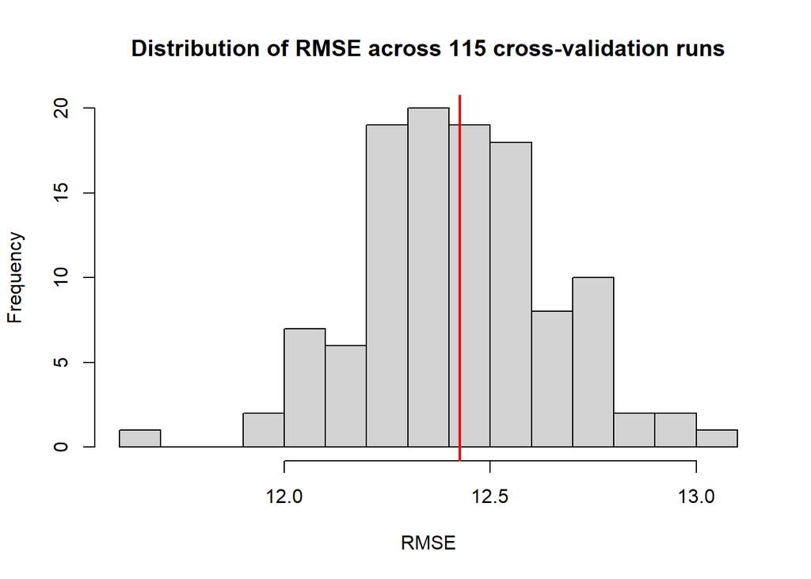

```r
hist(
  rmse_values,
  main = "Distribution of RMSE across 115 cross-validation runs",
  xlab = "RMSE",
  breaks = "FD"
)
abline(v = mean(rmse_values), col = "red", lwd = 2)
```